# ugao_eda_completed_final_01

🌱 Ugaoo - Exploratory Data Analysis

[figure not shown]

### Table of Contents :

- 1. Introduction
- 2. About Dataset & Problem
  - Project Overview
  - Dataset Overview
  - Business Problem
- 3. Data Preparation
  - Importing Libraries
  - Data Loading
  - Data Cleaning
- 4. Exploratory Data Analysis
  - Univariate Analysis
  - Bivariate Analysis
- 5. Key Insights
- 6. Business Recommendations
- 7. Conclusion
- 8. Thank You
2. Introduction

### Introduction

This project presents an exploratory data analysis of **Ugaoo's e-commerce sales data**. The objective of this analysis is to understand customer purchasing patterns, product performance, and key business drivers that influence profitability.

Through data exploration and visualization, the analysis highlights important insights related to product categories, regional demand, payment behavior, and discount impact on profit margins.

The findings from this analysis aim to support **data-driven decision making** for improving pricing strategies, product focus, and operational efficiency.

[figure not shown]

2. About Dataset & Problem

## Project Overview

This project analyzes transactional sales data from **Ugaoo**, an Indian gardening and plant e-commerce brand. The analysis focuses on understanding **sales performance, customer purchasing behavior, product category performance, regional demand patterns, and the impact of payment methods and discount strategies on profitability**.

By exploring historical order data, the objective is to uncover **key business insights** that can support better decision-making in pricing strategy, regional expansion, and product positioning.

## Dataset Overview

The dataset contains transactional sales records from Ugaoo’s e-commerce platform covering the period **2023–2025**. Each row represents an individual customer order including product, payment, and profitability information.

**Dataset Highlights**

• Total transactions analyzed: **18,000+ orders** • Time period covered: **2023 – 2025** • Granularity: **Order-level transaction data**

**Key Variables in the Dataset**

• Order Value • Product Category • State / Region • Payment Method • Discount Percentage • Profit Generated • Return Status

This dataset enables analysis of **profit drivers, customer behavior patterns, product performance, and operational risks** within Ugaoo’s online sales operations.

## Business Problem

Ugaoo’s e-commerce business has been experiencing uneven performance across different states, product categories, and order types between **2023–2025**. While order volume has grown, the company lacks clear visibility into the factors driving **profitability, product returns, and regional sales performance**.

To address this challenge, the analysis focuses on answering the following key business questions:

• Which **states and regions generate the highest revenue and profit** • Which **product categories drive the most business value** • How **payment methods influence order returns** • Whether **discount strategies are impacting profit margins**

This analysis aims to uncover these insights and support **data-driven decisions for pricing strategy, sales optimization, and operational efficiency**.

### **Data Preparation**

Before starting the analysis, the required Python libraries are imported to support data manipulation, analysis, and visualization tasks.

These libraries enable efficient handling of structured data and help generate visual insights from the dataset.

3. Importing Libraries

```python
# importing libraries
import pandas as pd
import numpy as np
import matplotlib.pyplot as plt
import seaborn as sns
```

### Data Loading

In this step, the dataset is loaded into the analysis environment to enable further data exploration and processing.

The dataset contains transactional sales records including order details, product categories, payment methods, discounts, and profit metrics.

4. Data Loading

```python
# uploading dataset
df =pd.read_csv(r"C:\Users\Asus\OneDrive\Desktop\Ugao_project\UGAO_India_Sales_Data_2023_2025.csv")
```

```python
# detailed information of each column - dtype , non-null values etc
df.info()
```

```
<class 'pandas.core.frame.DataFrame'>
RangeIndex: 18000 entries, 0 to 17999
Data columns (total 16 columns):
 #   Column            Non-Null Count  Dtype
---  ------            --------------  -----
 0   order_id          18000 non-null  int64
 1   order_date        18000 non-null  object
 2   city              18000 non-null  object
 3   state             18000 non-null  object
 4   category          18000 non-null  object
 5   quantity          18000 non-null  int64
 6   payment_mode      18000 non-null  object
 7   delivery_type     18000 non-null  object
 8   unit_price        18000 non-null  int64
 9   discount_percent  17460 non-null  float64
 10  final_price       18000 non-null  float64
 11  order_value       18000 non-null  float64
 12  delivery_days     18000 non-null  int64
 13  customer_rating   17460 non-null  float64
 14  is_returned       18000 non-null  object
 15  profit            18000 non-null  float64
dtypes: float64(5), int64(4), object(7)
memory usage: 2.2+ MB
```

```python
# descriptive statistics of numeric columns
df.describe()
```

|  | order_id | quantity | unit_price | discount_percent | final_price | order_value | delivery_days | customer_rating | profit |
| --- | --- | --- | --- | --- | --- | --- | --- | --- | --- |
| count | 18000.000000 | 18000.000000 | 18000.000000 | 17460.000000 | 18000.000000 | 18000.000000 | 18000.000000 | 17460.000000 | 18000.000000 |
| mean | 109000.500000 | 2.494833 | 430.801278 | 10.527205 | 385.376658 | 962.444364 | 4.423111 | 3.978528 | 240.793754 |
| std | 5196.296758 | 1.118550 | 119.316273 | 7.913061 | 112.210877 | 531.607346 | 2.193607 | 0.650688 | 147.585910 |
| min | 100001.000000 | 1.000000 | 199.000000 | 0.000000 | 150.000000 | 150.750000 | 1.000000 | 1.300000 | 26.780000 |
| 25% | 104500.750000 | 1.000000 | 335.000000 | 5.000000 | 297.750000 | 515.100000 | 3.000000 | 3.500000 | 123.382500 |
| 50% | 109000.500000 | 2.000000 | 424.000000 | 10.000000 | 377.000000 | 887.300000 | 4.000000 | 4.000000 | 209.430000 |
| 75% | 113500.250000 | 3.000000 | 517.000000 | 15.000000 | 465.075000 | 1299.150000 | 6.000000 | 4.500000 | 325.225000 |
| max | 118000.000000 | 4.000000 | 698.000000 | 25.000000 | 698.000000 | 2784.000000 | 8.000000 | 5.000000 | 955.300000 |

```python
# rows and columns size
df.shape
```

```
(18000, 16)
```

```python
df.sample(5)
```

|  | order_id | order_date | city | state | category | quantity | payment_mode | delivery_type | unit_price | discount_percent | final_price | order_value | delivery_days | customer_rating | is_returned | profit |
| --- | --- | --- | --- | --- | --- | --- | --- | --- | --- | --- | --- | --- | --- | --- | --- | --- |
| 302 | 100303 | 2024-09-04 | Chennai | Tamil Nadu | Flowering Plant | 3 | UPI | Standard | 640 | 5.0 | 608.00 | 1824.00 | 5 | 5.0 | No | 604.11 |
| 5338 | 105339 | 2025-10-28 | Jaipur | Rajasthan | Pot | 1 | UPI | Standard | 371 | 10.0 | 333.90 | 333.90 | 8 | 2.9 | No | 84.52 |
| 9667 | 109668 | 2023-04-28 | Indore | Madhya Pradesh | Succulent | 4 | COD | Standard | 296 | 10.0 | 266.40 | 1065.60 | 5 | 5.0 | No | 274.51 |
| 7188 | 107189 | 2023-06-13 | Bhopal | Madhya Pradesh | Flowering Plant | 1 | Card | Express | 609 | 25.0 | 456.75 | 456.75 | 1 | 4.6 | No | 122.66 |
| 14667 | 114668 | 2024-02-24 | Jaipur | Rajasthan | Flowering Plant | 1 | UPI | Express | 694 | 0.0 | 694.00 | 694.00 | 3 | 3.6 | No | 200.17 |

5. Data Cleaning

```python
df.columns
```

```
Index(['order_id', 'order_date', 'city', 'state', 'category', 'quantity',
       'payment_mode', 'delivery_type', 'unit_price', 'discount_percent',
       'final_price', 'order_value', 'delivery_days', 'customer_rating',
       'is_returned', 'profit'],
      dtype='object')
```

```python
# checeking any duplicates

df.duplicated().sum()
```

```
np.int64(0)
```

```python
# checking null values

df.isna().sum()
```

```
order_id              0
order_date            0
city                  0
state                 0
category              0
quantity              0
payment_mode          0
delivery_type         0
unit_price            0
discount_percent    540
final_price           0
order_value           0
delivery_days         0
customer_rating     540
is_returned           0
profit                0
dtype: int64
```

```python
df[["discount_percent","customer_rating"]].isna().sum()
```

```
discount_percent    540
customer_rating     540
dtype: int64
```

```python
# replacing null values with 0 in discount percent column as if discounted cell is empty that means no discount was provided.

df['discount_percent'] = df['discount_percent'].replace(np.nan, 0)
```

```python
# to cross check discount_percent missing values

df["discount_percent"].isna().sum()
```

```
np.int64(0)
```

```python
# null values in customerr_rating in dataset

df["customer_rating"].isna().sum()
```

```
np.int64(540)
```

```python
# replacing rows where customer rating is null with "No Rating"
df["customer_rating"] = df["customer_rating"].replace(np.nan,"No Rating")
```

```python
df.isnull().sum()
```

```
order_id            0
order_date          0
city                0
state               0
category            0
quantity            0
payment_mode        0
delivery_type       0
unit_price          0
discount_percent    0
final_price         0
order_value         0
delivery_days       0
customer_rating     0
is_returned         0
profit              0
dtype: int64
```

```python
# to check dtype of all column
df.dtypes
```

```
order_id              int64
order_date           object
city                 object
state                object
category             object
quantity              int64
payment_mode         object
delivery_type        object
unit_price            int64
discount_percent    float64
final_price         float64
order_value         float64
delivery_days         int64
customer_rating      object
is_returned          object
profit              float64
dtype: object
```

```python
# now change dtype of order_date

df["order_date"] = pd.to_datetime(df["order_date"])
```

```python
df.dtypes
```

```
order_id                     int64
order_date          datetime64[ns]
city                        object
state                       object
category                    object
quantity                     int64
payment_mode                object
delivery_type               object
unit_price                   int64
discount_percent           float64
final_price                float64
order_value                float64
delivery_days                int64
customer_rating             object
is_returned                 object
profit                     float64
dtype: object
```

outliers

```python
num_cols = [col for col in df.columns
            if df[col].dtype == 'object'
            and not np.issubdtype(df[col].dtype, np.datetime64)]
num_cols
```

```
['city',
 'state',
 'category',
 'payment_mode',
 'delivery_type',
 'customer_rating',
 'is_returned']
```

```python
# checking outliers in df
num_df = pd.DataFrame(num_cols)
```

```python
from useful_func import out_info
```

```python
out_info(num_df)
```

|  | col_name | method | num_out | out_% | ul | ll |
| --- | --- | --- | --- | --- | --- | --- |

**📊 Data Cleaning Summary**

- Checked for duplicate records and missing values.
- Missing values were identified in **discount_percent** and **customer_rating**.
- Null values were replaced with **0** and **"No rating"** respectively.
- Converted **order_date** from object to datetime.

6. Exploratory Data Analysis

### Exploratory Data Analysis

In this section, exploratory data analysis is performed to understand the distribution and patterns within the dataset.

The analysis focuses on:

• Distribution of key numerical variables  
• Frequency of categorical variables  
• Initial insights into sales and profit behavior

6.1 Univariate Analysis

```python
# to finalise all columns which are numerical

num_cols = [col for col in df.columns
            if df[col].dtype != 'object'
            and not np.issubdtype(df[col].dtype, np.datetime64)]
num_cols
```

```
['order_id',
 'quantity',
 'unit_price',
 'discount_percent',
 'final_price',
 'order_value',
 'delivery_days',
 'profit']
```

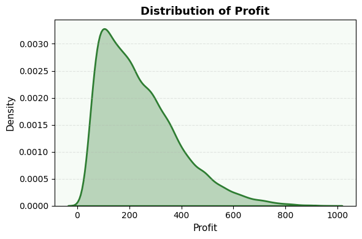

```python
plt.figure(figsize=(6,4))

sns.kdeplot(
    df["profit"],
    color="#2e7d32",   # Ugaoo green
    fill=True,
    alpha=0.3,
    linewidth=2
)

plt.xlabel("Profit", fontsize=11)
plt.ylabel("Density", fontsize=11)
plt.title("Distribution of Profit", fontsize=13, fontweight="bold")

# subtle grid
plt.grid(axis="y", linestyle="--", alpha=0.3)

# light natural background
plt.gca().set_facecolor("#f6fbf6")

plt.tight_layout()
plt.show()
```

```python
df["profit"].describe()
```

```
count    18000.000000
mean       240.793754
std        147.585910
min         26.780000
25%        123.382500
50%        209.430000
75%        325.225000
max        955.300000
Name: profit, dtype: float64
```

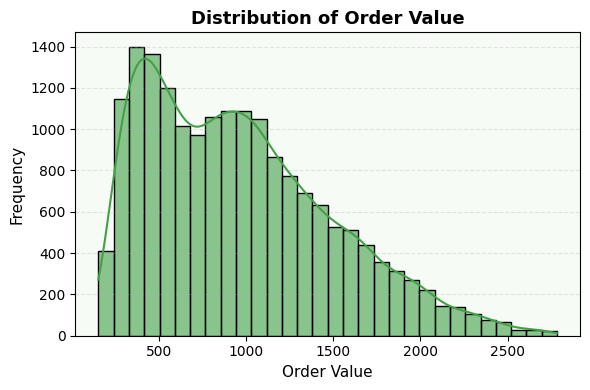

```python
plt.figure(figsize=(6,4))

sns.histplot(
    df["order_value"],
    kde=True,
    color="#43a047",
    bins=30,
    alpha=0.6
)

plt.xlabel("Order Value", fontsize=11)
plt.ylabel("Frequency", fontsize=11)
plt.title("Distribution of Order Value", fontsize=13, fontweight="bold")

plt.grid(axis="y", linestyle="--", alpha=0.3)

plt.gca().set_facecolor("#f6fbf6")

plt.tight_layout()
plt.show()
```

```python
df["order_value"].describe()
```

```
count    18000.000000
mean       962.444364
std        531.607346
min        150.750000
25%        515.100000
50%        887.300000
75%       1299.150000
max       2784.000000
Name: order_value, dtype: float64
```

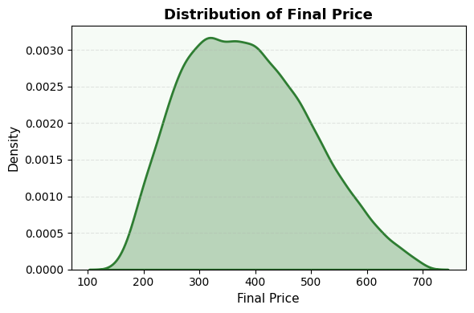

```python
plt.figure(figsize=(6,4))

sns.kdeplot(
    df["final_price"],
    color="#2e7d32",      # Ugaoo green
    fill=True,
    alpha=0.3,
    linewidth=2
)

plt.xlabel("Final Price", fontsize=11)
plt.ylabel("Density", fontsize=11)
plt.title("Distribution of Final Price", fontsize=13, fontweight="bold")

plt.grid(axis="y", linestyle="--", alpha=0.3)

plt.gca().set_facecolor("#f6fbf6")

plt.tight_layout()
plt.show()
```

```python
df["final_price"].describe()
```

```
count    18000.000000
mean       385.376658
std        112.210877
min        150.000000
25%        297.750000
50%        377.000000
75%        465.075000
max        698.000000
Name: final_price, dtype: float64
```

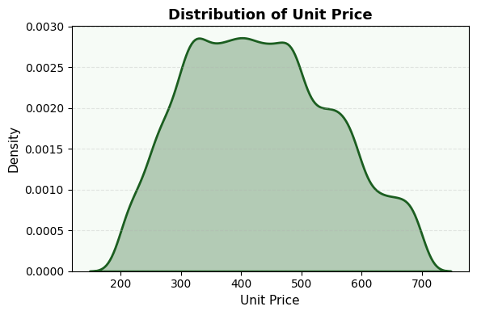

```python
plt.figure(figsize=(6,4))

sns.kdeplot(
    df["unit_price"],
    color="#1b5e20",
    fill=True,
    alpha=0.3,
    linewidth=2
)

plt.xlabel("Unit Price", fontsize=11)
plt.ylabel("Density", fontsize=11)
plt.title("Distribution of Unit Price", fontsize=13, fontweight="bold")

plt.grid(axis="y", linestyle="--", alpha=0.3)

plt.gca().set_facecolor("#f6fbf6")

plt.tight_layout()
plt.show()
```

```python
df["unit_price"].describe()
```

```
count    18000.000000
mean       430.801278
std        119.316273
min        199.000000
25%        335.000000
50%        424.000000
75%        517.000000
max        698.000000
Name: unit_price, dtype: float64
```

```python
df["delivery_days"].describe()
```

```
count    18000.000000
mean         4.423111
std          2.193607
min          1.000000
25%          3.000000
50%          4.000000
75%          6.000000
max          8.000000
Name: delivery_days, dtype: float64
```

```python
df.columns
```

```
Index(['order_id', 'order_date', 'city', 'state', 'category', 'quantity',
       'payment_mode', 'delivery_type', 'unit_price', 'discount_percent',
       'final_price', 'order_value', 'delivery_days', 'customer_rating',
       'is_returned', 'profit'],
      dtype='object')
```

**📊 Data Cleaning Summary**

- In column **Profit** it shows some values are at higher level which is valid transaction.
- In this **order_value** is right skewed which means values of some orders is high .
- In this , we can say that **final_price** is all lies between min and max value **i.e: 150 to 700**.
- Similarly in this **unit_price** is also between min and max range , there is not unexpected value in this .

## Bi-Variate Analysis

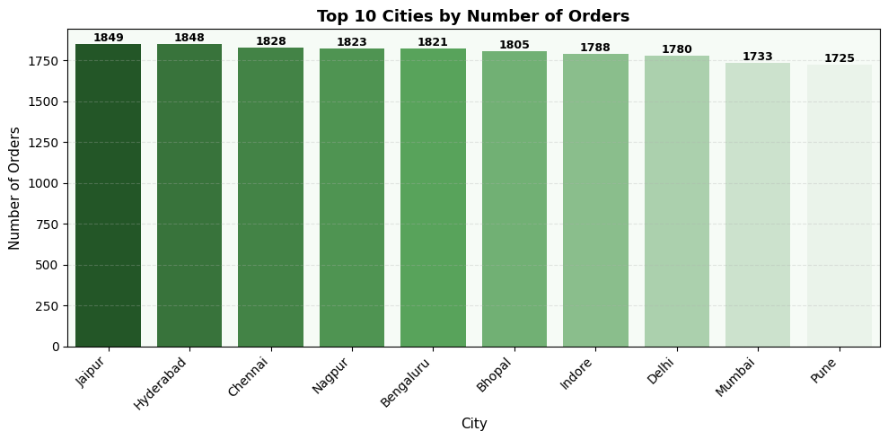

```python
# city wise orders
city_counts = df["city"].value_counts().head(10)

plt.figure(figsize=(10,5))

# Ugaoo green gradient palette for 10 bars
palette = [
"#1b5e20", "#2e7d32", "#388e3c", "#43a047", "#4caf50",
"#66bb6a", "#81c784", "#a5d6a7", "#c8e6c9", "#e8f5e9"
]

ax = sns.barplot(
    x=city_counts.index,
    y=city_counts.values,
    palette=palette
)

# value labels
for bar in ax.patches:
    ax.text(
        bar.get_x() + bar.get_width()/2,
        bar.get_height(),
        int(bar.get_height()),
        ha="center",
        va="bottom",
        fontsize=9,
        fontweight="bold"
    )

plt.xticks(rotation=45, ha="right")
plt.xlabel("City", fontsize=11)
plt.ylabel("Number of Orders", fontsize=11)
plt.title("Top 10 Cities by Number of Orders", fontsize=13, fontweight="bold")

# subtle grid
plt.grid(axis="y", linestyle="--", alpha=0.3)

# light natural background
plt.gca().set_facecolor("#f6fbf6")

plt.tight_layout()
plt.show()
```

**📌 Insights – City Performance**

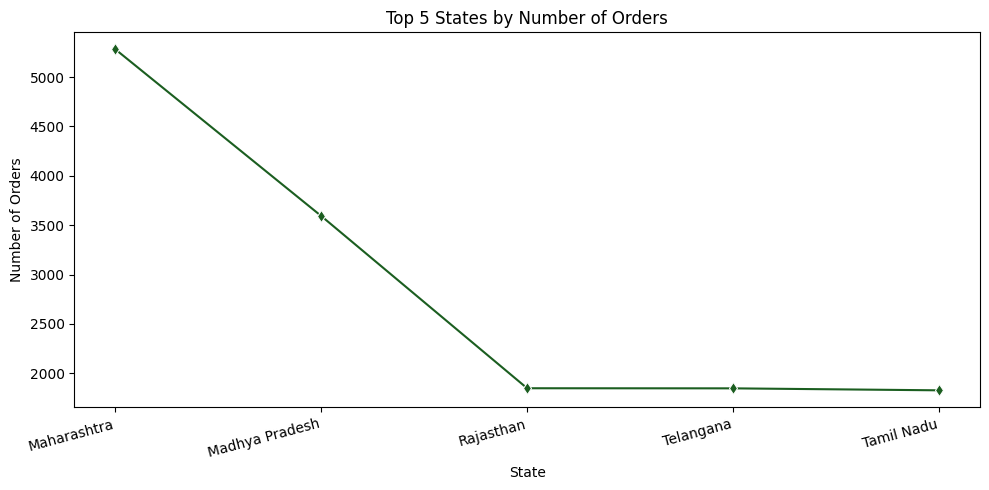

```python
# total orderrs for state wise

state_counts = df["state"].value_counts().head(5)

plt.figure(figsize=(10,5))
ax = sns.lineplot(
    x=state_counts.index,
    y=state_counts.values,
    marker = "d",
    color="#1B5E20"
)

for bar in ax.patches:
    ax.text(
        bar.get_x() + bar.get_width()/2,
        bar.get_height(),
        int(bar.get_height()),
        ha='center',
        va='bottom'
    )

plt.xticks(rotation=15, ha='right')
plt.xlabel("State")
plt.ylabel("Number of Orders")
plt.title("Top 5 States by Number of Orders")
plt.tight_layout()
plt.show()
```

**📌 Insights – State Demand**

- A small number of states dominate total orders.
- This suggests uneven geographical penetration.
- Expansion opportunities exist in low-performing states.

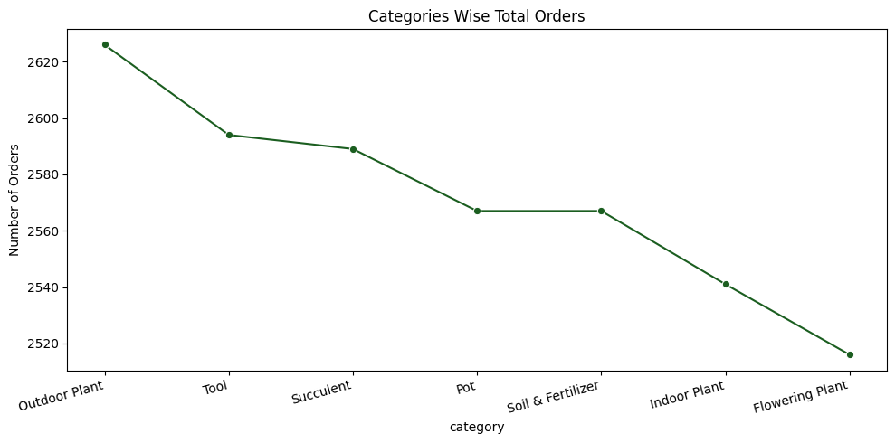

```python
# total orders as per category wise

category_counts = df["category"].value_counts()

plt.figure(figsize=(10,5))
ax = sns.lineplot(
    x=category_counts.index,
    y=category_counts.values,
    marker = "o",
    color = "#1B5E20"
)

for bar in ax.patches:
    ax.text(
        bar.get_x() + bar.get_width()/2,
        bar.get_height(),
        int(bar.get_height()),
        ha='center',
        va='bottom'
    )

plt.xticks(rotation=15, ha='right')
plt.xlabel("category")
plt.ylabel("Number of Orders")
plt.title("Categories Wise Total Orders")
plt.tight_layout()
plt.show()
```

**📌 Insights – Category Demand**

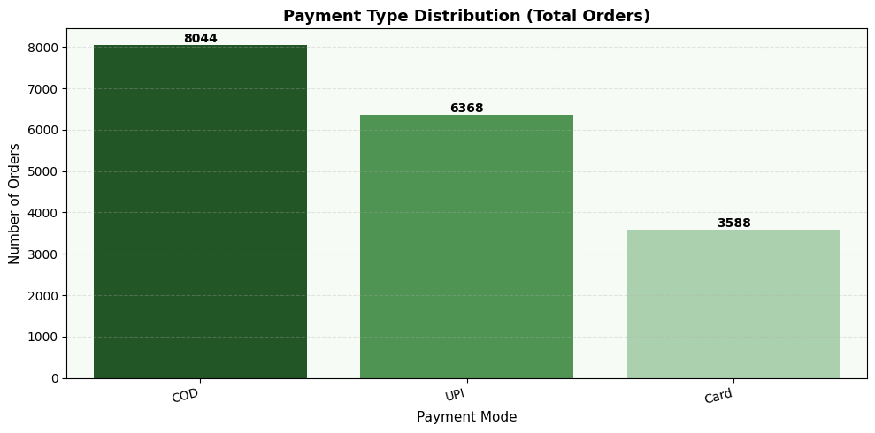

```python
payment_mode_counts = df["payment_mode"].value_counts()

plt.figure(figsize=(10,5))

# Ugaoo theme palette
palette = ["#1b5e20", "#43a047", "#a5d6a7"]

ax = sns.barplot(
    x=payment_mode_counts.index,
    y=payment_mode_counts.values,
    palette=palette
)

# value labels
for bar in ax.patches:
    ax.text(
        bar.get_x() + bar.get_width()/2,
        bar.get_height(),
        int(bar.get_height()),
        ha="center",
        va="bottom",
        fontsize=10,
        fontweight="bold"
    )

plt.xticks(rotation=15, ha="right")
plt.xlabel("Payment Mode", fontsize=11)
plt.ylabel("Number of Orders", fontsize=11)
plt.title("Payment Type Distribution (Total Orders)", fontsize=13, fontweight="bold")

# subtle grid
plt.grid(axis="y", linestyle="--", alpha=0.3)

# light nature background
plt.gca().set_facecolor("#f6fbf6")

plt.tight_layout()
plt.show()
```

**📌 Insights – Payment Preference**

- Cash on Delivery remains the most preferred payment method.
- Prepaid adoption is comparatively lower.
- Discounts on digital payments could improve cash flow and reduce returns.

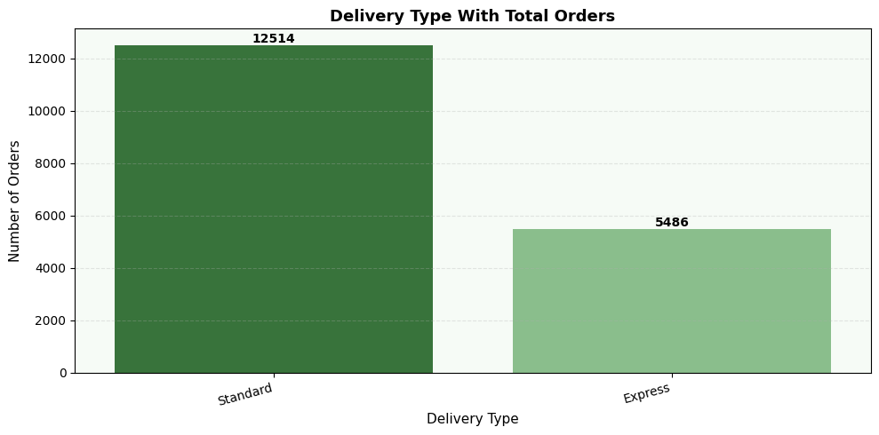

```python
delivery_type_counts = df["delivery_type"].value_counts()

plt.figure(figsize=(10,5))

# Ugaoo theme colors
palette = ["#2e7d32", "#81c784"]

ax = sns.barplot(
    x=delivery_type_counts.index,
    y=delivery_type_counts.values,
    palette=palette
)

# value labels
for bar in ax.patches:
    ax.text(
        bar.get_x() + bar.get_width()/2,
        bar.get_height(),
        int(bar.get_height()),
        ha="center",
        va="bottom",
        fontsize=10,
        fontweight="bold"
    )

plt.xticks(rotation=15, ha="right")
plt.xlabel("Delivery Type", fontsize=11)
plt.ylabel("Number of Orders", fontsize=11)
plt.title("Delivery Type With Total Orders", fontsize=13, fontweight="bold")

# subtle grid
plt.grid(axis="y", linestyle="--", alpha=0.3)

# soft background
plt.gca().set_facecolor("#f6fbf6")

plt.tight_layout()
plt.show()
```

**📌 Insights – Delivery Preference**

- Standard delivery handles the majority of shipments.
- Express delivery usage is limited.
- Customers may be price sensitive toward faster options.

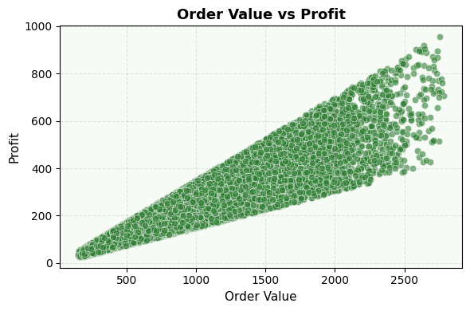

```python
plt.figure(figsize=(6,4))

sns.scatterplot(
    x=df["order_value"],
    y=df["profit"],
    color="#2e7d32",   # Ugaoo green
    alpha=0.6
)

plt.xlabel("Order Value", fontsize=11)
plt.ylabel("Profit", fontsize=11)
plt.title("Order Value vs Profit", fontsize=13, fontweight="bold")

# subtle grid
plt.grid(True, linestyle="--", alpha=0.3)

# light nature background
plt.gca().set_facecolor("#f6fbf6")

plt.tight_layout()
plt.show()
```

**📌 Insights – Profit Relationship**

- Higher order values generally lead to higher profits.
- However, variability increases for large orders.
- Monitoring discount strategies on high-value purchases is important.

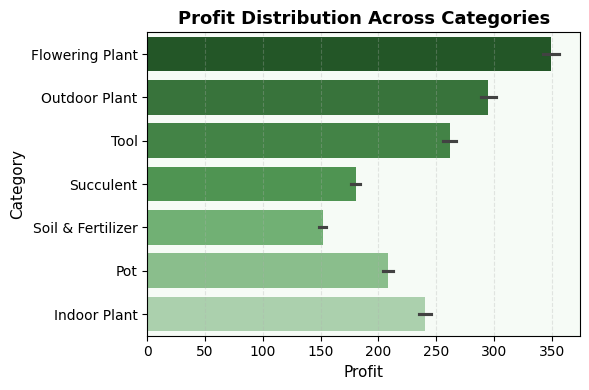

```python
plt.figure(figsize=(6,4))

# Ugaoo green palette
palette = ["#1b5e20", "#2e7d32", "#388e3c", "#43a047", "#66bb6a", "#81c784", "#a5d6a7"]

sns.barplot(
    x=df["profit"],
    y=df["category"],
    palette=palette
)

plt.xlabel("Profit", fontsize=11)
plt.ylabel("Category", fontsize=11)
plt.title("Profit Distribution Across Categories", fontsize=13, fontweight="bold")

# soft grid
plt.grid(axis="x", linestyle="--", alpha=0.3)

# light nature background
plt.gca().set_facecolor("#f6fbf6")

plt.tight_layout()
plt.show()
```

**📌 Insights – Profit Drivers**

- A few categories generate a disproportionate share of profit.
- Focusing marketing efforts here can maximize returns.
- Low-margin segments should be reviewed for cost optimization.

category wise profit contribution

```python
category_profit = df.groupby("category")["profit"].sum()

category_profit
```

```
category
Flowering Plant      878059.37
Indoor Plant         610083.87
Outdoor Plant        774654.29
Pot                  535112.13
Soil & Fertilizer    389595.53
Succulent            467800.32
Tool                 678982.07
Name: profit, dtype: float64
```

```python
total_profit = df["profit"].sum()
total_profit
```

```
np.float64(4334287.58)
```

```python
cont_cat_profit = category_profit/total_profit * 100

cont_cat_profit_sorted = cont_cat_profit.sort_values(ascending=False)
```

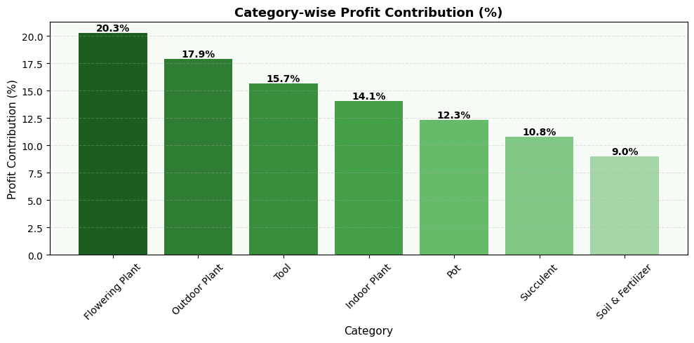

```python
plt.figure(figsize=(10,5))

# Ugaoo green gradient palette for multiple categories
colors = ["#1b5e20", "#2e7d32", "#388e3c", "#43a047", "#66bb6a", "#81c784", "#a5d6a7"]

bars = plt.bar(
    cont_cat_profit_sorted.index,
    cont_cat_profit_sorted.values,
    color=colors
)

plt.xlabel("Category", fontsize=11)
plt.ylabel("Profit Contribution (%)", fontsize=11)
plt.title("Category-wise Profit Contribution (%)", fontsize=13, fontweight="bold")

plt.xticks(rotation=45)

# value labels
for bar in bars:
    height = bar.get_height()
    plt.text(
        bar.get_x() + bar.get_width()/2,
        height,
        f"{height:.1f}%",
        ha="center",
        va="bottom",
        fontsize=10,
        fontweight="bold"
    )

# subtle grid
plt.grid(axis="y", linestyle="--", alpha=0.3)

# light nature background
plt.gca().set_facecolor("#f6fbf6")

plt.tight_layout()
plt.show()
```

**📌 Insights – Profit Drivers**

- A few categories generate a disproportionate share of profit.
- Focusing marketing efforts here can maximize returns.
- Low-margin segments should be reviewed for cost optimization.

city wise profit contribution

```python
city_profit = df.groupby("city")["profit"].sum().sort_values(ascending = False)
city_profit
```

```
city
Hyderabad    447486.51
Jaipur       446228.19
Nagpur       440629.23
Bengaluru    438684.07
Chennai      434583.87
Indore       434499.07
Bhopal       425149.40
Delhi        423568.53
Pune         422733.12
Mumbai       420725.59
Name: profit, dtype: float64
```

```python
cont_city_profit = city_profit/total_profit * 100
cont_city_profit.sorted = cont_city_profit.sort_values(ascending = False).head(5)
cont_city_profit.sorted
```

```
city
Hyderabad    10.324338
Jaipur       10.295306
Nagpur       10.166128
Bengaluru    10.121250
Chennai      10.026651
Name: profit, dtype: float64
```

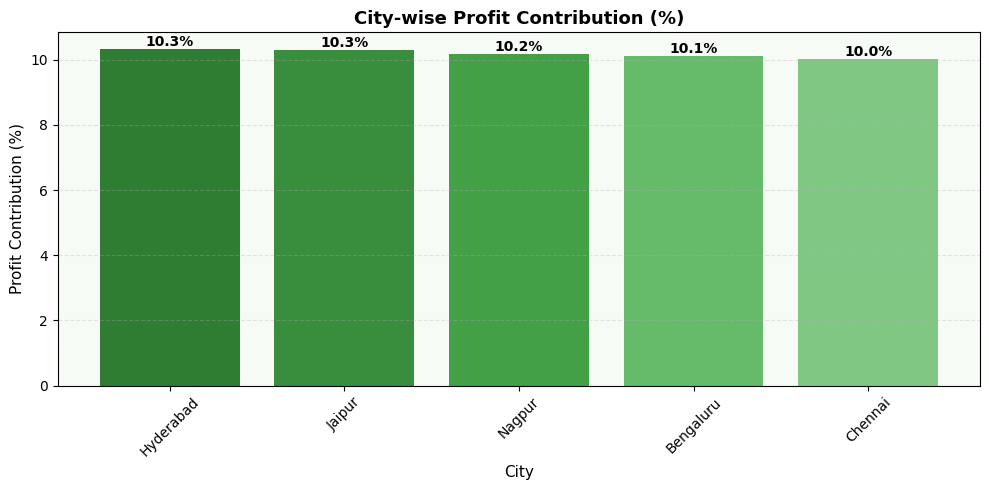

```python
plt.figure(figsize=(10,5))

# Ugaoo green palette
colors = ["#2e7d32", "#388e3c", "#43a047", "#66bb6a", "#81c784"]

bars = plt.bar(
    cont_city_profit.sorted.index,
    cont_city_profit.sorted.values,
    color=colors
)

plt.xlabel("City", fontsize=11)
plt.ylabel("Profit Contribution (%)", fontsize=11)
plt.title("City-wise Profit Contribution (%)", fontsize=13, fontweight="bold")

plt.xticks(rotation=45)

# value labels
for bar in bars:
    height = bar.get_height()
    plt.text(
        bar.get_x() + bar.get_width()/2,
        height,
        f"{height:.1f}%",
        ha="center",
        va="bottom",
        fontsize=10,
        fontweight="bold"
    )

plt.grid(axis="y", linestyle="--", alpha=0.3)

plt.gca().set_facecolor("#f6fbf6")

plt.tight_layout()
plt.show()
```

state wise contribution in profit

```python
state_profit = df.groupby("state")["profit"].sum().sort_values(ascending = False).head(5)
state_profit
```

```
state
Maharashtra       1284087.94
Madhya Pradesh     859648.47
Telangana          447486.51
Rajasthan          446228.19
Karnataka          438684.07
Name: profit, dtype: float64
```

```python
con_state_profit = state_profit/total_profit *100
con_state_profit = con_state_profit.sort_values(ascending=False).head(5)
con_state_profit
```

```
state
Maharashtra       29.626275
Madhya Pradesh    19.833674
Telangana         10.324338
Rajasthan         10.295306
Karnataka         10.121250
Name: profit, dtype: float64
```

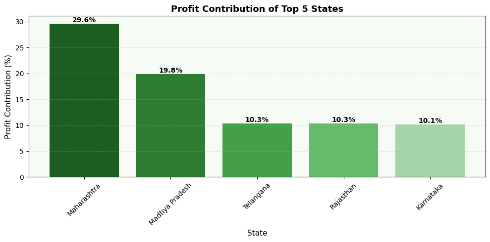

```python
plt.figure(figsize=(10,5))

# Ugaoo green gradient palette
colors = ["#1b5e20", "#2e7d32", "#43a047", "#66bb6a", "#a5d6a7"]

bars = plt.bar(
    con_state_profit.index,
    con_state_profit.values,
    color=colors
)

plt.xlabel("State", fontsize=11)
plt.ylabel("Profit Contribution (%)", fontsize=11)
plt.title("Profit Contribution of Top 5 States", fontsize=13, fontweight="bold")

plt.xticks(rotation=45)

# value labels
for bar in bars:
    height = bar.get_height()
    plt.text(
        bar.get_x() + bar.get_width()/2,
        height,
        f"{height:.1f}%",
        ha="center",
        va="bottom",
        fontsize=10,
        fontweight="bold"
    )

plt.grid(axis="y", linestyle="--", alpha=0.3)

# soft natural background
plt.gca().set_facecolor("#f6fbf6")

plt.tight_layout()
plt.show()
```

**📌 Insights – Regional Profitability**

- Profit is concentrated in a handful of states.
- These regions likely have better logistics and repeat buyers.
- Replication of strategies in other states could drive growth.

```python
del_profit = df.groupby("delivery_type")["profit"].sum()
```

```python
cont_del_profit = del_profit/total_profit * 100
cont_del_profit = cont_del_profit.sort_values(ascending = False)
cont_del_profit
```

```
delivery_type
Standard    69.346721
Express     30.653279
Name: profit, dtype: float64
```

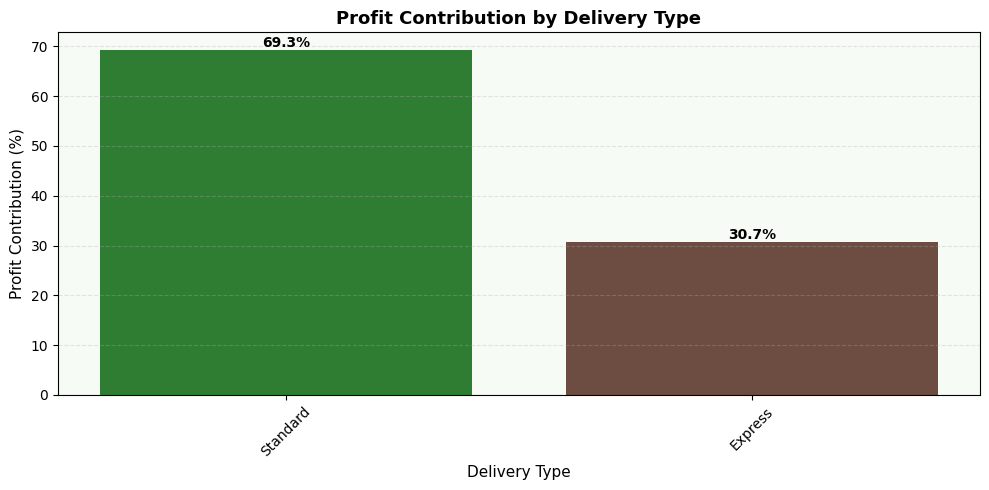

```python
plt.figure(figsize=(10,5))

# Ugaoo theme colors
colors = ["#2e7d32", "#6d4c41"]   # green (plants), brown (soil)

bars = plt.bar(
    cont_del_profit.index,
    cont_del_profit.values,
    color=colors
)

plt.xlabel("Delivery Type", fontsize=11)
plt.ylabel("Profit Contribution (%)", fontsize=11)
plt.title("Profit Contribution by Delivery Type", fontsize=13, fontweight="bold")

plt.xticks(rotation=45)

# value labels
for bar in bars:
    height = bar.get_height()
    plt.text(
        bar.get_x() + bar.get_width()/2,
        height,
        f"{height:.1f}%",
        ha="center",
        va="bottom",
        fontsize=10,
        fontweight="bold"
    )

# soft grid
plt.grid(axis="y", linestyle="--", alpha=0.3)

# light background for nature theme
plt.gca().set_facecolor("#f6fbf6")

plt.tight_layout()
plt.show()
```

**📌 Insights – Delivery Type Profitability**

```python
payment_mode_profit = df.groupby("payment_mode")["profit"].sum()
```

```python
cont_payment_made_profit = payment_mode_profit/total_profit * 100
cont_payment_made_profit = cont_payment_made_profit.sort_values(ascending=False)
cont_payment_made_profit
```

```
payment_mode
COD     44.962753
UPI     35.371653
Card    19.665594
Name: profit, dtype: float64
```

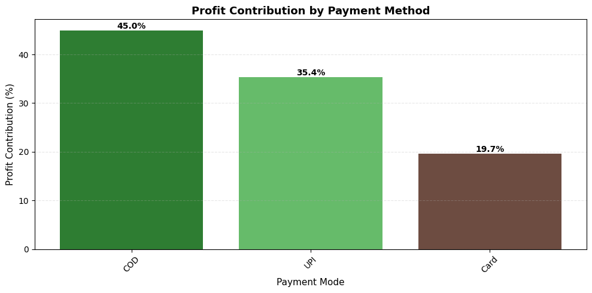

```python
plt.figure(figsize=(10,5))

# Ugaoo theme colors
colors = ["#2e7d32", "#66bb6a", "#6d4c41"]   # dark green, light green, brown

bars = plt.bar(
    cont_payment_made_profit.index,
    cont_payment_made_profit.values,
    color=colors
)

plt.xlabel("Payment Mode", fontsize=11)
plt.ylabel("Profit Contribution (%)", fontsize=11)
plt.title("Profit Contribution by Payment Method", fontsize=13, fontweight="bold")

plt.xticks(rotation=45)

# value labels on bars
for bar in bars:
    height = bar.get_height()
    plt.text(
        bar.get_x() + bar.get_width()/2,
        height,
        f"{height:.1f}%",
        ha="center",
        va="bottom",
        fontsize=10,
        fontweight="bold"
    )

plt.grid(axis="y", linestyle="--", alpha=0.3)

plt.tight_layout()
plt.show()
```

**📌 Insights – Payment Mode Profitability**

- Cash on Delivery contributes a significant portion of total profit.
- However, prepaid methods ensure faster settlements and lower operational risk.
- Increasing digital payment adoption could improve efficiency and working capital.

```python
print(df.columns)
```

```
Index(['order_id', 'order_date', 'city', 'state', 'category', 'quantity',
       'payment_mode', 'delivery_type', 'unit_price', 'discount_percent',
       'final_price', 'order_value', 'delivery_days', 'customer_rating',
       'is_returned', 'profit'],
      dtype='object')
```

## Payment Mode vs Product Returns

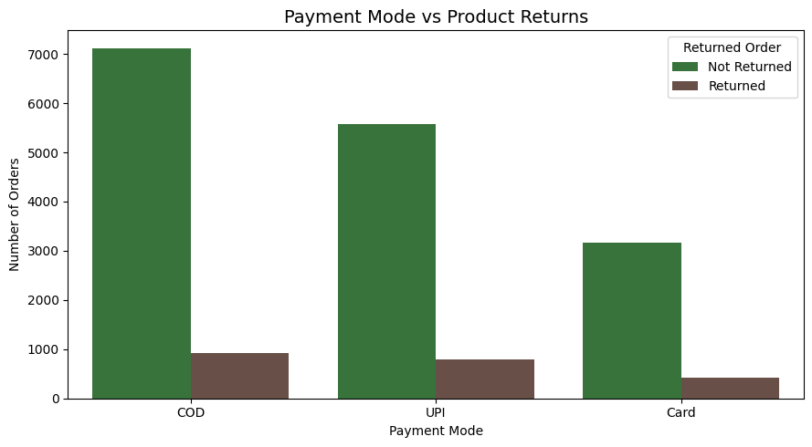

```python
import seaborn as sns
import matplotlib.pyplot as plt

plt.figure(figsize=(9,5))

sns.countplot(
    data=df,
    x='payment_mode',
    hue='is_returned',
    palette=['#2E7D32','#6D4C41']  # green and brown shades
)

plt.title("Payment Mode vs Product Returns", fontsize=14)
plt.xlabel("Payment Mode")
plt.ylabel("Number of Orders")

plt.legend(title="Returned Order", labels=["Not Returned","Returned"])

plt.tight_layout()
plt.show()
```

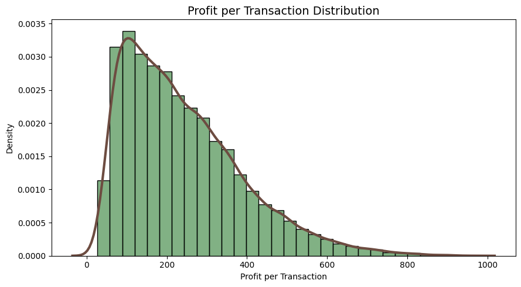

```python
import seaborn as sns
import matplotlib.pyplot as plt

plt.figure(figsize=(9,5))

# Histogram (green bars) - density scale
sns.histplot(
    data=df,
    x='profit',
    bins=30,
    stat="density",
    color='#2E7D32',
    alpha=0.6
)

# KDE trend line (brown)
sns.kdeplot(
    data=df,
    x='profit',
    color='#6D4C41',
    linewidth=3
)

plt.title("Profit per Transaction Distribution", fontsize=14)
plt.xlabel("Profit per Transaction")
plt.ylabel("Density")

plt.tight_layout()
plt.show()
```

#### 📌 Insights – Profit Distribution

- Most transactions generate moderate profit levels, indicating a stable pricing structure across products.
- A smaller number of transactions contribute significantly higher profits, likely associated with premium or bulk purchases.
- The right-skewed distribution suggests opportunities to improve margins by promoting higher-value products.

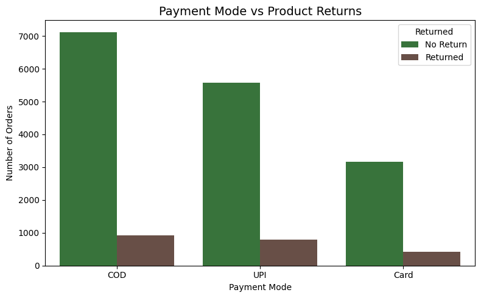

```python
import seaborn as sns
import matplotlib.pyplot as plt

plt.figure(figsize=(8,5))

sns.countplot(
    data=df,
    x='payment_mode',
    hue='is_returned',
    palette=['#2E7D32','#6D4C41']
)

plt.title("Payment Mode vs Product Returns", fontsize=14)
plt.xlabel("Payment Mode")
plt.ylabel("Number of Orders")

plt.legend(title="Returned", labels=["No Return","Returned"])

plt.tight_layout()
plt.show()
```

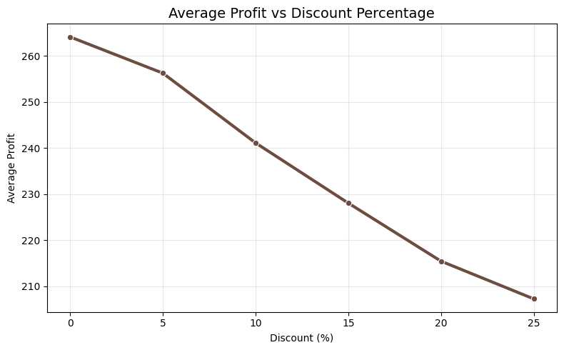

```python
import seaborn as sns
import matplotlib.pyplot as plt

# calculate average profit
discount_profit = df.groupby('discount_percent')['profit'].mean().reset_index()

plt.figure(figsize=(8,5))

sns.lineplot(
    data=discount_profit,
    x='discount_percent',
    y='profit',
    marker='o',
    color='#6D4C41',
    linewidth=3
)

plt.title("Average Profit vs Discount Percentage", fontsize=14)
plt.xlabel("Discount (%)")
plt.ylabel("Average Profit")

plt.grid(alpha=0.3)

plt.tight_layout()
plt.show()
```

#### 📌 Insights – Discount Strategy

- The chart shows a gradual decline in average profit as discount percentages increase.
- Lower discounts maintain stronger profit margins, while higher discounts reduce profitability.
- This suggests that aggressive discounting should be carefully managed to maintain sustainable margins.

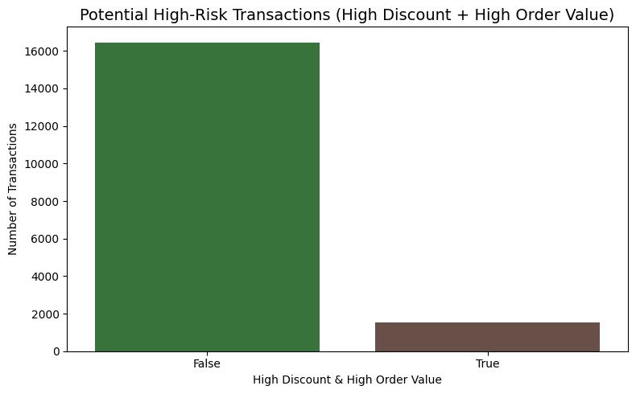

```python
import seaborn as sns
import matplotlib.pyplot as plt

# create risk flag
df['risk_flag'] = (df['discount_percent'] >= 20) & (df['order_value'] > df['order_value'].median())

plt.figure(figsize=(8,5))

sns.countplot(
    data=df,
    x='risk_flag',
    palette=['#2E7D32','#6D4C41']
)

plt.title("Potential High-Risk Transactions (High Discount + High Order Value)", fontsize=14)
plt.xlabel("High Discount & High Order Value")
plt.ylabel("Number of Transactions")

plt.tight_layout()
plt.show()
```

### Key Insights

• Profit contribution is highly concentrated geographically, with Maharashtra and Madhya Pradesh generating a significant share of total profit.

• Increasing discount levels are linked with declining profit margins, suggesting that aggressive promotional strategies may impact profitability.

### Business Recommendations

Based on the analysis of Ugaoo’s sales dataset, the following strategic recommendations can help improve business performance:

• **Expand high-performing regional strategies** by replicating successful sales and logistics approaches from Maharashtra and Madhya Pradesh in other emerging markets.

• **Prioritize high-margin product categories** such as Flowering Plants and Outdoor Plants through targeted marketing and inventory optimization.

• **Optimize discount strategies** by limiting excessive discounts and implementing controlled promotional campaigns to protect profit margins.

• **Monitor high-value discounted orders** more closely to reduce potential return risks and minimize revenue leakage.

🌱 Implementing these strategies can help strengthen profitability, reduce operational risks, and support sustainable growth for Ugaoo’s e-commerce operations.

### Conclusion

• Profit contribution is geographically concentrated, with Maharashtra and Madhya Pradesh generating nearly 50% of total profit, highlighting strong regional demand but also a need for broader market expansion.

• Increasing discount levels are directly linked with declining average profit margins, indicating that aggressive promotional strategies may erode profitability.

Overall, the analysis reveals key drivers of profitability and operational risk, providing actionable insights to support better pricing strategies, product prioritization, and regional sales optimization.

## **Thank You**

Thank you for reviewing this analysis of the **Ugaoo Sales Dataset**. This project demonstrates how data analysis can uncover meaningful business insights and support **data-driven decision making**.

🌿 Inspired by nature-driven business insights